# 7. Worksheet: Diversity Synthesis

Kelsey Coates; Quantitative Biodiversity, 2026

18 February, 2026

## OVERVIEW

In this worksheet, you will conduct exercises that reinforce fundamental concepts of biodiversity. First, you will construct a site-by-species matrix by sampling confectionery taxa from a source community. Second, you will make a preference-profile matrix, reflecting each student’s favorite confectionery taxa. With this primary data structure, you will then answer questions and generate figures using tools from previous weeks, along with wrangling techniques that we learned about in class.

## Directions:

1. In the Markdown version of this document in your cloned repo, change “Student Name” on line 3 (above) to your name.
2. Complete as much of the worksheet as possible during class.
3. Refer to previous handouts to help with developing of questions and writing of code.
4. Answer questions in the worksheet. Space for your answer is provided in this document and indicated by the “>” character. If you need a second paragraph be sure to start the first line with “>”. You should notice that the answer is highlighted in green by RStudio (color may vary if you changed the editor theme).
5. Before you leave the classroom, **push** this file to your GitHub repo.
6. For the assignment portion of the worksheet, follow the directions at the bottom of this file.
7. When you are done, **Knit** the text and code into a PDF file.
8. After Knitting, submit the completed exercise by creating a **pull request** via GitHub. Your pull request should include this file `7.DiversitySynthesis_Worskheet.Rmd` and the PDF output of `Knitr` (`DiversitySynthesis_Worskheet.pdf`).

## QUANTITATIVE CONFECTIONOLOGY

We will construct a site-by-species matrix using confectionery taxa (i.e, jelly beans). The instructors have created a **source community** with known abundance (*N*) and richness (*S*). Like a real biological community, the species abundances are unevenly distributed such that a few jelly bean types are common while most are rare. Each student will sample the source community and bin their jelly beans into operational taxonomic units (OTUs).

## SAMPLING PROTOCOL: SITE-BY-SPECIES MATRIX

1. From the well-mixed source community, each student should take one Dixie Cup full of individuals.
2. At your desk, sort the jelly beans into different types (i.e., OTUs), and quantify the abundance of each OTU.
3. Working with other students, merge data into a site-by-species matrix with dimensions equal to the number of students (rows) and taxa (columns)
4. Create a worksheet (e.g., Google sheet) and share the site-by-species matrix with the class.

### 1) R SETUP

In the R code chunk below, please provide the code to: 1) Clear your R environment, 2) Print your current working directory, 3) Set your working directory to your `Week5-Confection/` folder, and 4) Load the `vegan` R package (be sure to install first if you have not already).

```r
rm(list=ls())
getwd()
```

```
## [1] "C:/Users/coatesk23/OneDrive - East Carolina University/Documents/QuantBio/QB2026_Coates/Data Wrangling"
```

```r
setwd("C:/Users/coatesk23/OneDrive - East Carolina University/Documents/QuantBio/QB2026_Coates/Data Wrangling")
library(vegan)
```

```r
library(ggplot2)
library(tidyverse)
library(dplyr)
library(broom)
```

## DATA ANALYSIS

**Question 1:** In the space below, generate a rarefaction plot for all samples of the source community. Based on these results, discuss how individual vs. collective sampling efforts capture the diversity of the source community.

```r
jelly.source <- read.table("JellyBeans.Source.txt")
jelly.sub <- read.table("JellyBeans.Subsampled.txt",header = TRUE)
dat <- read.csv(file = "simulated.csv", header = TRUE, row.names = 1)

# Subset the even community
com_e_H <- diversity(dat[grepl("_even",row.names(dat)),], index = "shannon")
print(com_e_H)
```

```
## site1_even site2_even site3_even site4_even
##   3.563075   3.616117   3.543160   3.479093
```

```r
# Subset the uneven community
com_u_H <- diversity(dat[grepl("_uneven",row.names(dat)),], index = "shannon")
print(com_u_H)
```

```
## site1_uneven site2_uneven site3_uneven site4_uneven
##     2.964376     3.026223     2.828338     3.008247
```

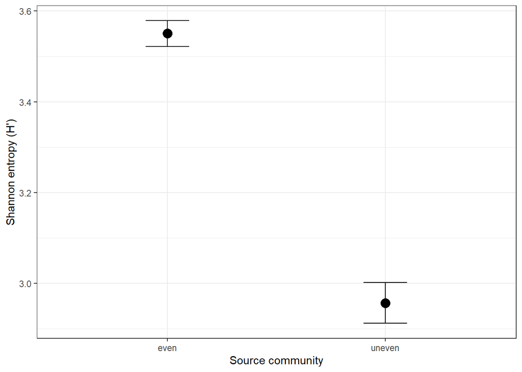

```r
# write function for SEM
SEM <- function(x) {
  return(sd(x)/sqrt(length(x)))
}

# The following code binds the two vectors as columns in a data frame
com_div_all <- t(cbind.data.frame(com_e_H, com_u_H))

# Rename the row names to be more intelligibl
row.names(com_div_all) <- c("even", "uneven")

# Create an empty data frame to fill with summary statistics
com_div_sum <- as.data.frame(matrix(ncol = 2 , nrow = 2))
colnames(com_div_sum) <- c("mean", 'sem')

# The following for loop will iteratively calculate
# the mean and standard error for each row, one at a time.
for(i in 1:2) {
  x = as.numeric(com_div_all[i,])
  com_div_sum[i,1] <- mean(x) # Calculate mean, save to diversity indices data
  com_div_sum[i,2] <- SEM(x)   # Calculate SEM, save to diversity indices data
}

# Let us add a grouping column to the data
com_div_sum$community <- c("even", "uneven")

ggplot(data = com_div_sum, aes(x = community, y = mean))+
  geom_point(size = 4)+
  geom_errorbar(aes(ymin = mean-sem, ymax = mean+sem), width = 0.2)+
  ylab("Shannon entropy (H')")+
  xlab("Source community")+
  theme_bw()
```

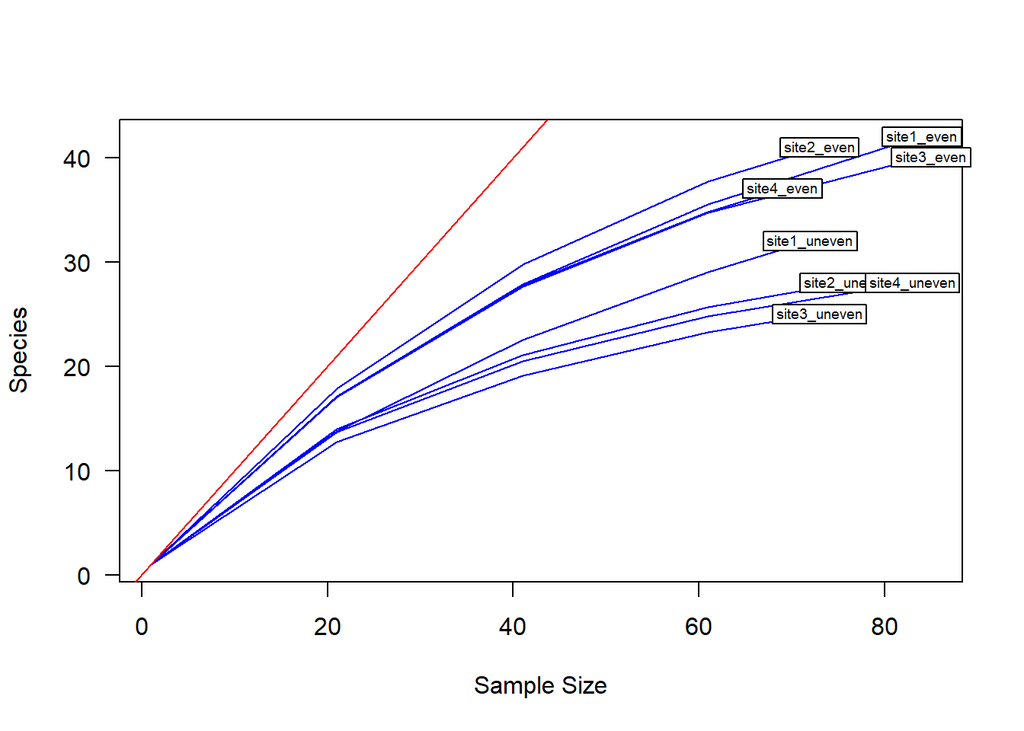

```r
#rarefaction
min.N <- min(rowSums(dat))

S.rarefy <- rarefy(x = dat, sample = min.N, se = TRUE)

rarecurve(x = dat, step = 20, col = "blue", cex = 0.6, las = 1)

abline(0, 1, col = 'red')

text(1500, 1500, "1:1", pos = 2, col = 'red')
```

> *Answer 1*: Individual sampling of a single site or sampling one time may underestimate richness and overestimate differences between sites. Sampling across sites and time should reveal the underlying community structure with better detection of rare species.

**Question 2:** Starting with the site-by-species matrix, visualize beta diversity. In the code chunk below, conduct principal coordinates analyses (PCoA) using both an abundance- and incidence-based resemblance matrix. Plot the sample scores in species space using different colors, symbols, or labels. Which “species” are contributing the patterns in the ordinations? How does the choice of resemblance matrix affect your interpretation?

```r
# Extract metadata
meta <- jelly.sub[, c("Group", "Site")]
# Extract species (color) columns
jellies <- jelly.sub %>% select(-Group, -Site)


beta.w <- function(site.by.species = ""){
  SbyS.pa <- decostand(site.by.species, method = "pa")
  # convert to presence-absence
  S <- ncol(SbyS.pa[,which(colSums(SbyS.pa) > 0)])
  # number of species in the region
  a.bar <- mean(specnumber(SbyS.pa))
  # average richness at each site
  b.w <- round(S/a.bar, 3)
  # round to 3 decimal places
  return(b.w)
}

beta.w(jellies) #1.273
```

```
## [1] 1.273
```

```r
# Calculate Bray-Curtis abundance
jelly.bca <- vegdist(jellies, method = "bray")
jelly.bca
```

```
##           1         2         3         4         5         6         7
## 2 0.2516129
## 3 0.2903226 0.3066667
## 4 0.3250000 0.3290323 0.2258065
## 5 0.3750000 0.4322581 0.2903226 0.2375000
## 6 0.1851852 0.2738854 0.2993631 0.3209877 0.3456790
## 7 0.3469388 0.3098592 0.3380282 0.3605442 0.3741497 0.3020134
## 8 0.3026316 0.2925170 0.2653061 0.2763158 0.3157895 0.2467532 0.2805755
## 9 0.4388489 0.3880597 0.3432836 0.2949640 0.3812950 0.3900709 0.3333333
##           8
## 2
## 3
## 4
## 5
## 6
## 7
## 8
## 9 0.2824427
```

```r
# Calculate Jaccard incidence
jelly.ji <- vegdist(jellies, method = "jaccard", binary = TRUE)
jelly.ji
```

```
##           1         2         3         4         5         6         7
## 2 0.2592593
## 3 0.3333333 0.3200000
## 4 0.1851852 0.2962963 0.2400000
## 5 0.2307692 0.3461538 0.2916667 0.3333333
## 6 0.2142857 0.2592593 0.3928571 0.2500000 0.2962963
## 7 0.3076923 0.3600000 0.3043478 0.3461538 0.3333333 0.3703704
## 8 0.2592593 0.3076923 0.3200000 0.2962963 0.2800000 0.2592593 0.2173913
## 9 0.3333333 0.3846154 0.4000000 0.3076923 0.4230769 0.3333333 0.5000000
##           8
## 2
## 3
## 4
## 5
## 6
## 7
## 8
## 9 0.3200000
```

```r
# abundance based PCOA
jelly.pcoa.a <- cmdscale(jelly.bca, eig = TRUE, k = 3)

explainvar1 <- round(jelly.pcoa.a$eig[1] / sum(jelly.pcoa.a$eig), 3) * 100
explainvar2 <- round(jelly.pcoa.a$eig[2] / sum(jelly.pcoa.a$eig), 3) * 100
explainvar3 <- round(jelly.pcoa.a$eig[3] / sum(jelly.pcoa.a$eig), 3) * 100
sum.eig <- sum(explainvar1, explainvar2, explainvar3)

# incidence based pcoa
jelly.pcoa.i <- cmdscale(jelly.ji, eig = TRUE, k = 3)

exp1_in <- round(jelly.pcoa.i$eig[1] / sum(jelly.pcoa.i$eig) * 100, 2)
exp2_in <- round(jelly.pcoa.i$eig[2] / sum(jelly.pcoa.i$eig) * 100, 2)
exp3_in <- round(jelly.pcoa.i$eig[3] / sum(jelly.pcoa.i$eig) * 100, 2)
```

```r
library(ggplot2)
fit_abund <- envfit(jelly.pcoa.a, jellies, permutations = 999)
fit_abund
```

```
##
## ***VECTORS
##
##                   Dim1     Dim2     r2 Pr(>r)
## Red           -0.06122  0.99812 0.5474  0.093 .
## RedShinny     -0.66884 -0.74341 0.0510  0.844
## OrangeSpe     -0.99795 -0.06393 0.8357  0.002 **
## OrangeDrk     -0.82685  0.56242 0.2667  0.422
## OrangeBrgt    -0.35470  0.93498 0.5919  0.083 .
## OrangeShn      0.73843 -0.67433 0.6702  0.041 *
## OrangeLight    0.94025 -0.34048 0.6702  0.041 *
## OrangSuperShn  0.24273 -0.97009 0.4544  0.161
## YellowSld      0.99902  0.04417 0.0348  0.903
## YellowTrans    0.90617 -0.42291 0.7452  0.014 *
## Watermellon   -0.49071 -0.87132 0.5452  0.092 .
## GreenTrans     0.94926 -0.31450 0.5943  0.063 .
## GreenTrans2   -0.98737  0.15843 0.3760  0.336
## GreenSoild     0.92189  0.38745 0.0646  0.811
## GreenSuperShn -0.08628 -0.99627 0.0927  0.727
## GreenMintCho  -0.99976 -0.02200 0.1118  0.690
## AquaSuperShn   0.54864  0.83606 0.1953  0.516
## BlueDrkShn     0.65837 -0.75270 0.6978  0.025 *
## BlueDrk       -0.80177 -0.59764 0.7442  0.013 *
## BlueMuted     -0.89047 -0.45504 0.4083  0.197
## PurpleShn     -0.05317 -0.99859 0.1532  0.629
## PurpleSpot     0.64649 -0.76292 0.6234  0.057 .
## PinkShn        0.29014 -0.95698 0.6289  0.044 *
## PinkSpot      -0.99901  0.04446 0.3789  0.236
## Rainbow       -0.82636 -0.56314 0.2611  0.433
## WhiteBrownSP  -0.19450  0.98090 0.4223  0.188
## WhiteSuperShn -0.12167  0.99257 0.1427  0.637
## WhiteSolid    -0.58285 -0.81258 0.3207  0.312
## ---
## Signif. codes:  0 '***' 0.001 '**' 0.01 '*' 0.05 '.' 0.1 ' ' 1
## Permutation: free
## Number of permutations: 999
```

```r
species_vec <- as.data.frame(fit_abund$vectors$arrows * 1)  # scaling factor
species_vec$Species <- rownames(species_vec)
colnames(species_vec)[1:2] <- c("PC1", "PC2")

#pcoa function
plot_pcoa <- function(pcoa_obj, metadata, title = "PCoA Plot") {
# Extract scores
scores <- as.data.frame(pcoa_obj$points)
# Add metadata
scores$Group <- metadata$Group
scores$Site <- metadata$Site

# Variance explained
exp1 <- round(pcoa_obj$eig[1] / sum(pcoa_obj$eig) * 100, 2)
exp2 <- round(pcoa_obj$eig[2] / sum(pcoa_obj$eig) * 100, 2)
# Plot
ggplot(scores, aes(PC1, PC2, color = Group, shape = Site)) + geom_point(size = 4) + labs( x = paste0("PCoA1 (", exp1, "%)"), y = paste0("PCoA2 (", exp2, "%)"), title = title ) + theme_minimal() }

# Extract scores
scores <- as.data.frame(jelly.pcoa.a$points)
colnames(scores)[1:2] <- c("PC1", "PC2")




#plot(jelly.pcoa.a$points, pch = 19, col = meta$Group)
#plot(fit_abund, p.max = 0.05, col = "red") # only significant species
fit_abund$vectors$arrows
```

```
##                      Dim1        Dim2
## Red           -0.06122431  0.99812403
## RedShinny     -0.66883558 -0.74341036
## OrangeSpe     -0.99795461 -0.06392656
## OrangeDrk     -0.82685148  0.56242033
## OrangeBrgt    -0.35469588  0.93498173
## OrangeShn      0.73843246 -0.67432745
## OrangeLight    0.94025338 -0.34047553
## OrangSuperShn  0.24272763 -0.97009448
## YellowSld      0.99902417  0.04416684
## YellowTrans    0.90616942 -0.42291486
## Watermellon   -0.49071467 -0.87132033
## GreenTrans     0.94925699 -0.31450146
## GreenTrans2   -0.98736945  0.15843473
## GreenSoild     0.92189056  0.38745039
## GreenSuperShn -0.08627637 -0.99627124
## GreenMintCho  -0.99975804 -0.02199693
## AquaSuperShn   0.54864337  0.83605649
## BlueDrkShn     0.65836669 -0.75269735
## BlueDrk       -0.80176735 -0.59763627
## BlueMuted     -0.89047055 -0.45504089
## PurpleShn     -0.05317074 -0.99858544
## PurpleSpot     0.64649027 -0.76292223
## PinkShn        0.29014210 -0.95698357
## PinkSpot      -0.99901127  0.04445771
## Rainbow       -0.82636222 -0.56313896
## WhiteBrownSP  -0.19449826  0.98090286
## WhiteSuperShn -0.12166660  0.99257102
## WhiteSolid    -0.58285094 -0.81257909
## attr(,"parameters")
## attr(,"parameters")$norm
##  [1]  9.223332  1.735140 24.181007  2.748274 15.040864 10.256198 10.037733
##  [8]  6.669323  2.663007 14.634672 15.497531 11.592133  2.070700  2.513413
## [15]  2.126092  2.552296  4.372826  8.331215 28.098720  9.049808  2.103308
## [22] 10.782200 10.543016  6.215643  2.884959  6.526056  1.685094  2.386145
##
## attr(,"parameters")$margin
## [1] 2
##
## attr(,"decostand")
## [1] "normalize"
```

```r
# abundance based:

#a <- plot_pcoa(jelly.pcoa.a, meta,
#          title = "PCoA – Abundance-based (Bray–Curtis)")
#print(a)

#j <- plot_pcoa(jelly.pcoa.i, meta, "PCoA – Jaccard")
#print(j)

p <- plot_pcoa_with_vectors <- function(pcoa_obj, metadata, species_vectors, title = "PCoA Plot") {

  scores <- as.data.frame(pcoa_obj$points)
  colnames(scores)[1:2] <- c("PC1", "PC2")

  scores$Group <- metadata$Group
  scores$Site  <- metadata$Site

  exp1 <- round(pcoa_obj$eig[1] / sum(pcoa_obj$eig) * 100, 2)
  exp2 <- round(pcoa_obj$eig[2] / sum(pcoa_obj$eig) * 100, 2)

  ggplot(scores, aes(PC1, PC2, color = Group, shape = Site)) +
    geom_point(size = 4) +

    # species arrows
    geom_segment(data = species_vectors,
                 aes(x = 0, y = 0, xend = PC1, yend = PC2),
                 arrow = arrow(length = unit(0.25, "cm")),
                 color = "black") +

    # species labels
    geom_text(data = species_vectors,
              aes(x = PC1, y = PC2, label = Species),
              color = "black", size = 3, vjust = -0.5) +

    labs(
      x = paste0("PCoA1 (", exp1, "%)"),
      y = paste0("PCoA2 (", exp2, "%)"),
      title = title
    ) +
    theme_minimal()
}

print(p)
```

[output not shown]

**Question 3** Using the preference-profile matrix, determine the most popular jelly bean in the class using a control structure (e.g., for loop, if statement, function, etc).

**Question 4** In the code chunk below, identify the student in QB who has a preference-profile that is most like yours. Quantitatively, how similar are you to your “jelly buddy”? Visualize the preference profiles of the class by creating a cluster dendogram. Label each terminal node (a.k.a., tip or “leaf”) with the student’s name or initials. Make some observations about the preference-profiles of the class.

## SUBMITTING YOUR ASSIGNMENT

Use Knitr to create a PDF of your completed `7.DiversitySynthesis_Worksheet.Rmd` document, push it to GitHub, and create a pull request. Please make sure your updated repo includes both the pdf and RMarkdown files.